# MicrobiomeScopingReview

JW Debelius; Y Chen; Y Sun; Z Li

2025-01-31

```r
library(tidyverse)
library(tableone)
library(readxl)
library(ComplexUpset)
library(ggplot2)
library(patchwork)
#library(grid)
#library(gridExtra)
```

# Reading in the data

We’ll start by reading in the data and a manually prepared summary table.

```r
data <- read.csv('../data/LiChenScoping_data.tsv', sep='\t',
                 colClasses = 'character') %>%
   tibble() %>%
  mutate_all(., ~replace(., . %in% c('', 'NA'), NA))
dim(data)
```

```
## [1]  60 211
```

We’ll start by loading the studies that were collected from the citations document

```r
citations <- read_excel('../data/LiChenScopingCitations.xlsx') %>%
  select(., -(c(DOI...13))) %>%
  filter(., `Covidence #` %in% data$covidence_number) %>%
  rename(all_of(c(doi='DOI...1', covidence_number='Covidence #'))) %>%
  mutate(., in_title = (grepl('meta-ana', tolower(Title)) |
                        grepl('meta ana', tolower(Title)))
          , in_abstract = (grepl('meta-ana', tolower(Abstract)) |
                           grepl('meta ana', tolower(Abstract)))) %>%
  mutate(., meta_in_title_abs = (in_title | in_abstract) * 1
          , in_title = in_title * 1
          , in_abstract = in_abstract * 1
    )
```

# Table 1

I want to consturct a summary document based on what Lianne did. We’ll start by tabulating the purpose, both overall and by intersections.

```r
purpose.df <- data %>%
  select(c('doi',  starts_with('meta_purpose'))) %>%
  rename_with(., .fn=~str_remove(., 'meta_purpose.'), .cols=starts_with('meta_purpose.')) %>%
  rename_with(,, .fn=~str_remove(., '\\.')) %>%
  mutate_at(., .vars=vars(-c(doi, meta_purpose_other)), .funs=as.numeric) %>%
  mutate(., core_microbiome = replace(core_microbiome, doi == '10.3389/fcimb.2021.645951', 0)) %>%
  mutate(., num_resp = replication_validation + core_microbiome + population_synthesis + other) %>%
  mutate(., purpose = case_when(other == 1 & num_resp == 1 ~ 'other'
                               ,replication_validation == 1 & num_resp == 1 ~ 'replication_validation'
                               ,core_microbiome == 1 & num_resp == 1 ~ 'core_microbiome'
                               ,population_synthesis == 1 & num_resp == 1 ~ 'population_synthesis'
                               ,population_synthesis == 1 & core_microbiome == 1 & num_resp == 2 ~ 'population_synthesis + core_microbiome'
                               ,population_synthesis == 1 & replication_validation == 1 & num_resp == 2 ~ 'population_synthesis + replication_validation'
                               ,.default='oopsie')
          )

purpose.df %>% group_by(purpose) %>% count()
```

```
## # A tibble: 6 × 2
## # Groups:   purpose [6]
##   purpose                                           n
##   <chr>                                         <int>
## 1 core_microbiome                                   1
## 2 other                                             3
## 3 population_synthesis                             47
## 4 population_synthesis + core_microbiome            4
## 5 population_synthesis + replication_validation     2
## 6 replication_validation                            3
```

```r
purpose.df %>% summarise(across(-c(doi, num_resp, purpose, meta_purpose_other), sum)) %>%
  pivot_longer(cols=everything(), names_to='step', values_to='count') %>%
  mutate(., percent = round(count / 60, 2))
```

```
## # A tibble: 6 × 3
##   step                   count percent
##   <chr>                  <dbl>   <dbl>
## 1 replication_validation     5    0.08
## 2 core_microbiome            5    0.08
## 3 population_synthesis      53    0.88
## 4 not_meta                   0    0
## 5 not_described              0    0
## 6 other                      3    0.05
```

```r
purpose.df %>% filter(other == 1) %>%
  select(c(doi, meta_purpose_other))
```

```
## # A tibble: 3 × 2
##   doi                          meta_purpose_other
##   <chr>                        <chr>
## 1 10.1371/journal.pcbi.1004468 Comparison of enviromental similarity
## 2 10.1371/journal.pcbi.1010066 Evaluate a method
## 3 10.1073/pnas.1000080107      To check the perfromance of a new technique
```

```r
goal.df <- data %>%
  select(c('doi', starts_with('meta_goal'))) %>%
  rename_with(., .fn=~str_remove(., 'meta_goal.'), .cols=starts_with('meta_goal.')) %>%
  rename_with(,, .fn=~str_remove(., '\\.')) %>%
  mutate_at(., .vars=vars(-c(doi, meta_goal_other)), .funs=as.numeric) %>%
  mutate(., num_resp = (microbiome_outcome + microbiome_exposure + assembly +
                        unqiue_microbiome + other)) %>%
  mutate(., goal = case_when(microbiome_outcome == 1 & num_resp == 1 ~ 'outcome'
                            ,microbiome_exposure == 1 & num_resp == 1 ~ 'exposure'
                            ,assembly == 1 & num_resp == 1 ~ 'assembly'
                            ,unqiue_microbiome == 1 & num_resp == 1 ~ 'unique_microbiome'
                            ,other == 1 & num_resp == 1 ~ 'other'
                            ,microbiome_outcome == 1 & microbiome_exposure == 1 ~ 'outcome + exposure'
                            ,microbiome_outcome == 1 & assembly == 1 ~ 'outcome + assembly'
                            ,microbiome_outcome == 1 & unqiue_microbiome == 1 ~ 'outcome + unique'
                            ,microbiome_outcome == 1 & other == 1 ~ 'outcome + other'
                            ,microbiome_exposure == 1 & assembly == 1 ~ 'exposure + assembly'
                            ,microbiome_exposure == 1 & unqiue_microbiome == 1 ~ 'exposure + unique'
                            ,microbiome_exposure == 1 & other == 1 ~ 'exposure + other'
                            ,assembly == 1 & unqiue_microbiome == 1 ~ 'assembly + unique'
                            ,assembly == 1 & other == 1 ~ 'assembly + other'
                            ,unqiue_microbiome == 1 & other == 1 ~ 'unique + other'
                            ,.default = 'oopsie'

                            )
        )
```

```r
goal.df %>% summarise(across(-c(doi, num_resp, goal, meta_goal_other), sum)) %>%
  pivot_longer(cols=everything(), names_to='step', values_to='count') %>%
  mutate(., percent = round(count / 60, 2))
```

```
## # A tibble: 5 × 3
##   step                count percent
##   <chr>               <dbl>   <dbl>
## 1 microbiome_outcome     41    0.68
## 2 microbiome_exposure    12    0.2
## 3 assembly                5    0.08
## 4 unqiue_microbiome       6    0.1
## 5 other                   6    0.1
```

```r
(goal.df %>% filter(other == 1) %>%
  select(c(doi, meta_goal_other)))$meta_goal_other
```

```
## [1] "identify inter- and intra-individual differences and similarities between the GM composition of particular mouse strains and humans"
## [2] "microbiome-metabolite association"
## [3] "Cross comparison between many enviroments"
## [4] "Characterize a method"
## [5] "To compare enviroments"
## [6] " to identify overall patterns that drive differences in the human microbiota and to ascertain the degree to which technical variability between studies impacts observed diversity"
```

```r
envo.df <- data %>%
  select(c(doi, starts_with('envo.'), 'envo_other')) %>%
  mutate_at(., .vars=vars(starts_with('envo.')), .funs=as.numeric) %>%
  rename_with(., .fn=~str_remove(., 'envo.'), .cols=starts_with('envo.')) %>%
  rename_with(,, .fn=~str_remove(., '\\.')) %>%
  arrange(., desc(host)) %>%
  mutate(., envo = case_when(!is.na(envo_other) & envo_other != 'plants' ~ 'multi enviroment'
                             ,built_envo == 1 ~ 'human + built enviroment'
                             ,host == 1 ~ 'human + host_assoc'
                             ,.default = 'human')
  )
envo.df %>%
  group_by(envo) %>% count() %>%
  mutate(., perc = round(n / 60, 2))
```

```
## # A tibble: 3 × 3
## # Groups:   envo [3]
##   envo                   n  perc
##   <chr>              <int> <dbl>
## 1 human                 54  0.9
## 2 human + host_assoc     3  0.05
## 3 multi enviroment       3  0.05
```

```r
envo.bs <- data %>%
  select(c(doi, envo_other, starts_with('envo_bodysite'))) %>%
  mutate_at(., .vars=vars(starts_with('envo_bodysite.')), .funs=as.numeric) %>%
  rename_with(., .fn=~str_remove(., 'envo_bodysite.'), .cols=starts_with('envo_bodysite.')) %>%
  rename_with(,, .fn=~str_remove(., '\\.')) %>%
  mutate(., num_resp = gut + oral + skin + urogenital + airway
          , pan_enviromental = !is.na(envo_other) * 1) %>%
  arrange(desc(num_resp)) %>%
  mutate(., body_site = case_when(!is.na(envo_other) ~ 'multiple enviroments'
                            ,num_resp == 5 ~ 'gut + oral + skin + urogenital + airway'
                            ,gut == 1 & oral == 1 & skin == 1 ~ 'gut + oral + skin'
                            ,gut == 1 & oral == 1 & urogenital == 1 ~ 'gut + oral + urogenital'
                            ,gut == 1 & oral == 1 ~ 'gut + oral'
                            ,gut == 1 & skin == 1 ~ 'gut + skin'
                            ,gut == 1 & urogenital == 1 ~ 'gut + urogenital'
                            ,gut == 1 & airway == 1 ~ 'gut + airway'
                            ,oral == 1 & skin == 1~ 'oral + oral + skin'
                            ,oral == 1 & urogenital == 1 ~ 'oral + urogenital'
                            ,oral == 1 & airway == 1 ~ 'oral + airway'
                            ,skin == 1 & urogenital == 1 ~ 'skin + urogenital'
                            ,skin == 1 & airway == 1 ~ 'skin + airway'
                            ,urogenital == 1 & airway == 1 ~ 'urogenital + airway'
                            ,gut == 1 & num_resp == 1 ~ 'gut'
                            ,oral == 1 & num_resp == 1 ~ 'oral'
                            ,skin == 1 & num_resp == 1 ~ 'skin'
                            ,urogenital == 1 & num_resp == 1 ~ 'urogenital'
                            ,airway == 1 & num_resp == 1 ~ 'airway'
                            ,.default = 'oopsie!'
                            )) %>%
  mutate(., body_site_simp = case_when(gut == 1 & num_resp == 2 ~ 'gut with other body site'
                                      ,gut == 1 & num_resp == 1 ~ 'gut'
                                      ,num_resp > 2 ~ '≥3 body sites'
                                      #,num_resp == 2 ~ 'multiple other sites'
                                      ,!is.na(envo_other) ~ 'multiple enviroments'
                                      ,.default =  'other'))
envo.bs %>%
  select(-c(doi, body_site, body_site_simp, envo_other, envo_bodysite_other, num_resp)) %>%
  summarise(across(everything(), sum)) %>%
  pivot_longer(cols=everything(), names_to='step', values_to='count') %>%
  mutate(., percent = round(count / 60, 2)) %>%
  arrange(desc(count))
```

```
## # A tibble: 7 × 3
##   step             count percent
##   <chr>            <dbl>   <dbl>
## 1 gut                 50    0.83
## 2 oral                 9    0.15
## 3 airway               8    0.13
## 4 urogenital           7    0.12
## 5 skin                 5    0.08
## 6 pan_enviromental     4    0.07
## 7 other                1    0.02
```

```r
envo.bs %>% group_by(body_site_simp) %>% count() %>%
  mutate(., perc = round(n / 60, 2))
```

```
## # A tibble: 5 × 3
## # Groups:   body_site_simp [5]
##   body_site_simp               n  perc
##   <chr>                    <int> <dbl>
## 1 gut                         42  0.7
## 2 gut with other body site     3  0.05
## 3 multiple enviroments         1  0.02
## 4 other                        9  0.15
## 5 ≥3 body sites                5  0.08
```

```r
num.studies <- data %>%
  select(c(doi, num_studies_1o, num_samples_1o, validation, num_studies_valid, num_sample_validation)) %>%
  mutate(., num_samples_1o = ifelse(grepl('=',num_samples_1o), str_split_i(num_samples_1o, '=', -1), num_samples_1o)) %>%
  mutate_at(., .vars=vars(starts_with('num')), .funs=as.numeric) %>%
  mutate(., num_studies_valid = replace(num_studies_valid, validation == 'No', NA)
          , num_sample_validation = replace(num_sample_validation, validation == 'No', NA)
          ) %>%
  mutate(., num_studies_cat = case_when(is.na(num_studies_1o) ~ 'not described'
                                        #,num_studies_1o == 1 ~ ' 1'
                                        #,num_studies_1o == 2 ~ ' 2'
                                        ,num_studies_1o <= 5 ~ ' <=5'
                                        ,num_studies_1o <= 10 ~ ' 6-10'
                                        ,num_studies_1o <= 15 ~ '11-15'
                                        ,.default = '15+')
         , num_samples_cat = case_when(is.na(num_samples_1o) ~ 'not described'
                                       ,num_samples_1o <= 500 ~ '<500'
                                       ,num_samples_1o <= 1500 ~ '501 - 1500'
                                       ,num_samples_1o <= 2500 ~ '1501 - 2500'
                                       ,.default = '≥2500'
                                       )
         , num_studies_vcat = case_when(validation != "Yes" ~ 'no validation'
                                       ,is.na(num_studies_valid) ~ 'not described'
                                       ,num_studies_valid == 1 ~ '1'
                                       ,num_studies_valid == 2 ~ '2'
                                       ,.default = '3 or more')
         , num_samples_vcat = case_when(validation != "Yes" ~ 'no validation'
                                        ,is.na(num_sample_validation) ~ 'not described'
                                       ,num_sample_validation < 100 ~ '<100'
                                       ,num_sample_validation < 200 ~ '100-199'
                                       ,num_sample_validation < 500 ~ '200-499'
                                       ,.default = '≥500')
    )
```

```r
num.studies %>%
  group_by(num_samples_cat) %>% count() %>%
  mutate(., perc = round(n / 60, 2))
```

```
## # A tibble: 5 × 3
## # Groups:   num_samples_cat [5]
##   num_samples_cat     n  perc
##   <chr>           <int> <dbl>
## 1 1501 - 2500        10  0.17
## 2 501 - 1500         12  0.2
## 3 <500               13  0.22
## 4 not described      11  0.18
## 5 ≥2500              14  0.23
```

```r
num.studies %>% select(num_studies_1o) %>%
  filter(!is.na(num_studies_1o)) %>%
  summarise(mean = mean(num_studies_1o)
           ,std = sd(num_studies_1o)
           ,min = min(num_studies_1o)
           ,q1 = quantile(num_studies_1o, 0.25)
           ,median = quantile(num_studies_1o, 0.5)
           ,q3 = quantile(num_studies_1o, 0.75)
           ,max = max(num_studies_1o)
           , count = n())
```

```
## # A tibble: 1 × 8
##    mean   std   min    q1 median    q3   max count
##   <dbl> <dbl> <dbl> <dbl>  <dbl> <dbl> <dbl> <int>
## 1  54.3  325.     1     4     10    15  2462    57
```

```r
num.studies %>% select(num_studies_valid) %>%
  filter(!is.na(num_studies_valid)) %>%
  summarise(mean = mean(num_studies_valid)
           ,std = sd(num_studies_valid)
           ,min = min(num_studies_valid)
           ,q1 = quantile(num_studies_valid, 0.25)
           ,median = quantile(num_studies_valid, 0.5)
           ,q3 = quantile(num_studies_valid, 0.75)
           ,max = max(num_studies_valid)
           ,count = n()
  )
```

```
## # A tibble: 1 × 8
##    mean   std   min    q1 median    q3   max count
##   <dbl> <dbl> <dbl> <dbl>  <dbl> <dbl> <dbl> <int>
## 1  2.17  1.60     1     1    1.5  2.75     5     6
```

```r
num.studies %>%
  group_by(num_studies_cat) %>% count() %>%
  mutate(., perc = round(n / 60, 2))
```

```
## # A tibble: 5 × 3
## # Groups:   num_studies_cat [5]
##   num_studies_cat     n  perc
##   <chr>           <int> <dbl>
## 1 " 6-10"             9  0.15
## 2 " <=5"             22  0.37
## 3 "11-15"            13  0.22
## 4 "15+"              13  0.22
## 5 "not described"     3  0.05
```

```r
num.studies %>%
  mutate(., validation = tolower(validation)) %>%
  group_by(validation) %>% count() %>%
  mutate(., perc = round(n / 60, 2))
```

```
## # A tibble: 2 × 3
## # Groups:   validation [2]
##   validation     n  perc
##   <chr>      <int> <dbl>
## 1 no            52  0.87
## 2 yes            8  0.13
```

# Dataset descriptions

## Systematic Appraoch to data

Here, we want to understand if there was a systematic approach to data, particularly among studies that were focused on an association with outcome or exposure grouping.

```r
scoping <- data %>%
  mutate_at(., .vars=vars(starts_with('meta_purpose.'), starts_with('meta_goal.')),
               .funs=as.numeric) %>%
   mutate(., other_goal = as.integer(meta_goal.assembly. == 1 |
                                     meta_goal.unqiue_microbiome. == 1 |
                                     meta_goal.other. == 1)
          ) %>%
  mutate(., D = case_when(
    meta_goal.microbiome_exposure. == 1 & meta_goal.microbiome_outcome. == 0 &  other_goal== 0 ~ "exposure",
    meta_goal.microbiome_outcome. == 1 & meta_goal.microbiome_exposure. == 0 & other_goal == 0 ~ "outcome",
    meta_goal.microbiome_outcome. == 1 & meta_goal.microbiome_exposure. == 1 & other_goal == 0 ~ "exposure+ outcome",
    meta_goal.microbiome_exposure. == 1 & other_goal == 1           ~ "exposure+other",
    meta_goal.microbiome_outcome. == 1 & other_goal == 1           ~ "outcome+other",
    other_goal == 1 & meta_goal.microbiome_outcome. == 0 & meta_goal.microbiome_exposure. == 0 ~ "other",
    TRUE                      ~ NA_character_  # for all other cases
  ))
```

We start by pulling out studies where the focus was linking an outcome or exposure to the microbiome.

```r
counts=table(scoping$D)
total=60
percentages <- (counts / total) * 100
result <- data.frame(Count = counts, Percentage = percentages)
scoping_exposureoutcome <- scoping %>% filter(D != "other")
dim(scoping_exposureoutcome)
```

```
## [1]  51 213
```

I want to start by checking how many of these studies desribed themselves as meta analyses either in the title or abstract.

```r
scoping_exposureoutcome <-
  scoping %>% filter(., D != 'other') %>%
  left_join(., citations[, c('covidence_number', 'Abstract')],
            join_by(covidence_number)) %>%
  mutate(., in_title = (grepl('meta-ana', tolower(title)) |
                        grepl('meta ana', tolower(title))),
          , in_abs = (grepl('meta-ana', tolower(Abstract)) |
                      grepl('meta ana', tolower(Abstract)))
    ) %>%
  mutate(., in_title_or_abstract = (in_title | in_abs) * 1)
```

I want to know how many of the articles have “meta-ana” or “meta ana” in the title or abstract of the data.

```r
table(scoping_exposureoutcome$in_title_or_abstract)
```

```
##
##  0  1
##  5 46
```

```r
mean(scoping_exposureoutcome$in_title_or_abstract)
```

```
## [1] 0.9019608
```

And then we’ll check the number of participants who did anything systematic

```r
table(scoping_exposureoutcome$systematic_approach)
```

```
##
##   No  Yes Yes?
##   26   24    1
```

```r
scoping_exposureoutcome %>%
  group_by(systematic_approach, in_title_or_abstract) %>%
  count() %>%
  ungroup() %>%
  pivot_wider(id_cols = systematic_approach,
              names_from = in_title_or_abstract,
              values_from = n,
              values_fill = 0)
```

```
## # A tibble: 3 × 3
##   systematic_approach   `0`   `1`
##   <chr>               <int> <int>
## 1 No                      3    23
## 2 Yes                     2    22
## 3 Yes?                    0     1
```

And then we have the search strategy within the “Yes” group:

```r
scoping_exposureoutcome %>%
  mutate(., search_described = replace(search_described,
                                       is.na(search_described), 'No')) %>%
  group_by(systematic_approach, search_described) %>%
  count()
```

```
## # A tibble: 4 × 3
## # Groups:   systematic_approach, search_described [4]
##   systematic_approach search_described     n
##   <chr>               <chr>            <int>
## 1 No                  No                  26
## 2 Yes                 No                   4
## 3 Yes                 Yes                 20
## 4 Yes?                No                   1
```

```r
scoping_exposureoutcome %>%
  mutate(., search_described = replace(search_described,
                                       is.na(search_described), 'No')) %>%
  group_by(search_described) %>%
  count()
```

```
## # A tibble: 2 × 2
## # Groups:   search_described [2]
##   search_described     n
##   <chr>            <int>
## 1 No                  31
## 2 Yes                 20
```

Whether a PRISMA diagram was included:

```r
scoping_exposureoutcome %>%
  mutate(., prisma_included = replace(prisma_included,
                                       is.na(prisma_included), 'No')) %>%
  group_by(systematic_approach, prisma_included) %>%
  count()
```

```
## # A tibble: 4 × 3
## # Groups:   systematic_approach, prisma_included [4]
##   systematic_approach prisma_included     n
##   <chr>               <chr>           <int>
## 1 No                  No                 26
## 2 Yes                 No                 11
## 3 Yes                 Yes                13
## 4 Yes?                No                  1
```

```r
scoping_exposureoutcome %>%
  mutate(., prisma_included = replace(prisma_included,
                                       is.na(prisma_included), 'No')) %>%
  group_by(prisma_included) %>%
  count()
```

```
## # A tibble: 2 × 2
## # Groups:   prisma_included [2]
##   prisma_included     n
##   <chr>           <int>
## 1 No                 38
## 2 Yes                13
```

And whether the inclusion/exclusion criteria were described.

```r
scoping_exposureoutcome %>%
  mutate(., study_inclusion = replace(study_inclusion,
                                       is.na(study_inclusion), 'No')) %>%
  group_by(systematic_approach, study_inclusion) %>%
  count()
```

```
## # A tibble: 3 × 3
## # Groups:   systematic_approach, study_inclusion [3]
##   systematic_approach study_inclusion     n
##   <chr>               <chr>           <int>
## 1 No                  No                 26
## 2 Yes                 Yes                24
## 3 Yes?                No                  1
```

```r
scoping_exposureoutcome %>%
  mutate(., study_inclusion = replace(study_inclusion,
                                       is.na(study_inclusion), 'No')) %>%
  group_by(study_inclusion) %>%
  count()
```

```
## # A tibble: 2 × 2
## # Groups:   study_inclusion [2]
##   study_inclusion     n
##   <chr>           <int>
## 1 No                 27
## 2 Yes                24
```

And then I’d like to pull out the data sets that described thesmelves a meta analyses but were performed for replication.

```r
scoping %>%
  left_join(., citations[, c('covidence_number', 'meta_in_title_abs')],
            by = join_by(covidence_number)) %>%
  filter(., meta_in_title_abs == 1) %>%
  filter(., meta_purpose.replication_validation. == 1) %>%
  select(., c(doi, title))
```

```
## # A tibble: 5 × 2
##   doi                           title
##   <chr>                         <chr>
## 1 10.3390/microorganisms9102149 Predicting the Role of the Human Gut Microbiome…
## 2 10.1038/s41598-020-69537-3    Metagenomic analysis of gut microbiota in non-t…
## 3 10.1002/mds.28119             Meta-Analysis of Gut Dysbiosis in Parkinson's D…
## 4 10.1186/s13059-016-1052-7     Heritable components of the human fecal microbi…
## 5 10.1186/s40168-017-0368-1     Identifying predictive features of Clostridium …
```

## Elements Described

We also want to know what information was summarized about the included data sets.

### Design information

The study design for each data set.

```r
table(scoping_exposureoutcome$design_info.population.)
```

```
##
##  0  1
## 12 39
```

### Sampling method

Sample collection

```r
table(scoping_exposureoutcome$design_info.sampling_method.)
```

```
##
##  0  1
## 41 10
```

### Extraction Kit

```r
table(scoping_exposureoutcome$design_info.extraction_kit.)
```

```
##
##  0  1
## 40 11
```

### Number of hypervariable regions

```r
table(scoping_exposureoutcome$design_info.hypervariable_region.)
```

```
##
##  0  1
##  8 43
```

### Sequencers used

```r
table(scoping_exposureoutcome$design_info.sequencer.)
```

```
##
##  0  1
## 14 37
```

# Data Sources

Look at data sources and clean up the data

```r
ds.rename <- function(c){
  c.new <- str_remove(c, 'sources_1o\\.')
  c.new <- str_remove(c.new, '\\.')
  return(c.new)
}
column.names <- c(SRA = 'sources_1o.SRA.'
                  ,ENA = 'sources_1o.ena.'
                  ,MG_RAST  = 'sources_1o.mg_rast.'
                  ,request_to_authors_original  = 'sources_1o.request_authors.'
                  ,consortium_authors = 'sources_1o.consortium_authors.'
                  ,QIIMEDB_or_Qiita  = 'sources_1o.qitta.'
                  ,other  = 'sources_1o.other.'
                  ,not_described = 'sources_1o.not_described.'
                  ,other_freetext  = 'sources_1o_other'
                  )

data.sources <- data %>%
  tibble() %>%
  select(c(covidence_number, starts_with('sources_1o'))) %>%
  mutate(., sources_1o_other = ifelse(`sources_1o.not_described.` == 'EBI',
                                      paste(sources_1o_other, 'ENA'),
                                      sources_1o_other)
              , sources_1o.not_described. = ifelse(sources_1o.not_described. == 'EBI', 0,
                                                   sources_1o.not_described.)
              ) %>%
  mutate_at(., .vars=vars(starts_with('sources_1o.')), .funs=as.numeric) %>%
  mutate_at(., .vars=vars(starts_with('sources_1o.')), ~replace(., is.na(.), 0)) %>%
  rename_with(., .fn = ds.rename, .cols = contains('sources_1o.')) %>%
  mutate(., sra_ena = ((SRA + ena) > 0) * 1)
```

### Open and closed data sources

I wnat the total number of data sources and the percentage

```r
data.sources %>%
  select(consortium_authors:not_described) %>%
  summarise(across(consortium_authors:not_described, sum))
```

```
## # A tibble: 1 × 8
##   consortium_authors   SRA   ena request_authors mg_rast qiita other
##                <dbl> <dbl> <dbl>           <dbl>   <dbl> <dbl> <dbl>
## 1                 14    39    14              19       4     7    13
## # ℹ 1 more variable: not_described <dbl>
```

```r
data.sources %>%
  select(consortium_authors:not_described) %>%
  summarise(across(consortium_authors:not_described, mean)) %>%
  mutate_all(., ~round(., 3) * 100)
```

```
## # A tibble: 1 × 8
##   consortium_authors   SRA   ena request_authors mg_rast qiita other
##                <dbl> <dbl> <dbl>           <dbl>   <dbl> <dbl> <dbl>
## 1               23.3    65  23.3            31.7     6.7  11.7  21.7
## # ℹ 1 more variable: not_described <dbl>
```

We consider SRA, ENA, Qiita, and MG-RAST as open source.

```r
data.sources %>%
    mutate(., open_source = ((SRA + ena + mg_rast + qiita) > 0) * 1
          , closed_source = ((request_authors + consortium_authors) > 0) * 1
         ) %>%
  mutate(., only_open = ((open_source == 1) & ((closed_source + other + not_described) == 0)) * 1
          , only_closed = ((closed_source == 1) & ((open_source + other + not_described) == 0)) * 1
          , open_other = (((open_source + other) > 0) & ((closed_source + not_described) == 0)) * 1
          , closed_other = (((closed_source + other) > 0) & ((open_source + not_described) == 0)) * 1
          ) %>%
  summarize(across(open_source:closed_other, sum)) %>%
  pivot_longer(., everything(), names_to = 'data_type', values_to = 'count') %>%
  mutate(., percent = round(count / dim(data.sources)[1], 3))
```

```
## # A tibble: 6 × 3
##   data_type     count percent
##   <chr>         <dbl>   <dbl>
## 1 open_source      43   0.717
## 2 closed_source    33   0.55
## 3 only_open        17   0.283
## 4 only_closed      10   0.167
## 5 open_other       23   0.383
## 6 closed_other     10   0.167
```

We also want to look at the “other” sources

```r
data.sources %>%
  filter(., (other == 1) | !is.na(sources_1o_other)) %>%
  select(., sources_1o_other)
```

```
## # A tibble: 15 × 1
##    sources_1o_other
##    <chr>
##  1 "CNGB"
##  2 "Github"
##  3 "American Gut Project"
##  4 "Dryad (personal communication?)"
##  5 "The processed data was uploaded to ImmPort"
##  6 "Dyrad"
##  7  <NA>
##  8 "NCBI"
##  9 "Mendeley, Supplemental Information, project website"
## 10 "henceforth(Chaffron dataset), locally sampled data"
## 11 "DDJB, MG-RAST "
## 12 "0"
## 13 "dbGaP"
## 14 "NA ENA"
## 15 "Microbiome CRC biomarker study repository"
```

### Upset of Data Sources

We’ll generate an upset plot for 5 data sources:

- “authors_meta_analysis_or_consortium”
- “Request_to_authors_original”
- “MG_RAST”
- “QIIMEDB_or_Qiita”
- “SRA/ENA”

```r
source.sets <- c("consortium_authors",
                 "request_authors",
                 "mg_rast",
                 "qiita",
                 "sra_ena")
```

The UpSet plot is configured with a specific ratio for the main bar,and the order of elements is determined by degree. The sizes of the points and lines in the plot are adjusted for visibility. The order of the sets is kept as defined (i.e., the order is not changed according to the counts). The scale of the text in different parts of the plot is adjusted for legibility. Labels are set for the main bar y-axis and the sets x-axis to describe the counts they represent.

```r
sets <- list('MG-RAST', 'Qiita', 'SRA/ENA', 'Request to authors', 'Consortium')
intersections <- list('Consortium'
                     ,c('Consortium', 'Request to authors')
                     ,c('Consortium', 'Request to authors', 'SRA/ENA')
                     ,c('Consortium', 'Request to authors', 'Qiita')
                     ,c('Consortium', 'Request to authors', 'SRA/ENA', 'Qiita')
                     ,c('Consortium', 'Request to authors', 'MG-RAST')
                     ,c('Consortium', 'Request to authors', 'SRA/ENA', 'MG-RAST')
                     ,c('Consortium', 'Request to authors', 'SRA/ENA', 'Qiita', 'MG-RAST')
                     ,c('Consortium', 'SRA/ENA')
                     ,c('Consortium', 'SRA/ENA', 'Qiita')
                     ,c('Consortium', 'SRA/ENA', 'MG-RAST')
                     ,c('Consortium', 'SRA/ENA', 'Qiita', 'MG-RAST')
                     ,c('Consortium', 'Qiita')
                     ,c('Consortium', 'Qiita', 'MG-RAST')
                     ,c('Consortium', 'MG-RAST')
                     ,'Request to authors'
                     ,c('Request to authors', 'SRA/ENA')
                     ,c('Request to authors', 'SRA/ENA', 'Qiita')
                     ,c('Request to authors', 'SRA/ENA', 'Qiita', 'MG-RAST')
                     ,c('Request to authors', 'SRA/ENA', 'MG-RAST')
                     ,c('Request to authors', 'Qiita')
                     ,c('Request to authors', 'Qiita', 'MG-RAST')
                     ,c('Request to authors', 'MG-RAST')
                     ,'SRA/ENA'
                     ,c('SRA/ENA', 'Qiita')
                     ,c('SRA/ENA', 'Qiita', 'MG-RAST')
                     ,c('SRA/ENA', 'MG-RAST')
                     ,'Qiita'
                     ,c('Qiita', 'MG-RAST')
                     ,'MG-RAST'
                     ,'Outside of known sets'
                     )

data.set2 <- sub.sources.upset <- data.sources %>%
  select(all_of(source.sets)) %>%
  rename(all_of(c(`Request to authors` = 'request_authors'
                  ,`MG-RAST` = 'mg_rast'
                  ,`Qiita` = 'qiita'
                  ,`Consortium` = 'consortium_authors'
                  , `SRA/ENA` = 'sra_ena')))

data.set2
```

```
## # A tibble: 60 × 5
##    Consortium `Request to authors` `MG-RAST` Qiita `SRA/ENA`
##         <dbl>                <dbl>     <dbl> <dbl>     <dbl>
##  1          1                    0         0     0         1
##  2          0                    0         0     0         1
##  3          1                    0         0     0         0
##  4          0                    1         0     1         1
##  5          0                    0         0     0         1
##  6          0                    0         1     0         1
##  7          0                    0         0     0         1
##  8          1                    0         0     0         1
##  9          0                    0         0     1         0
## 10          0                    0         0     0         0
## # ℹ 50 more rows
```

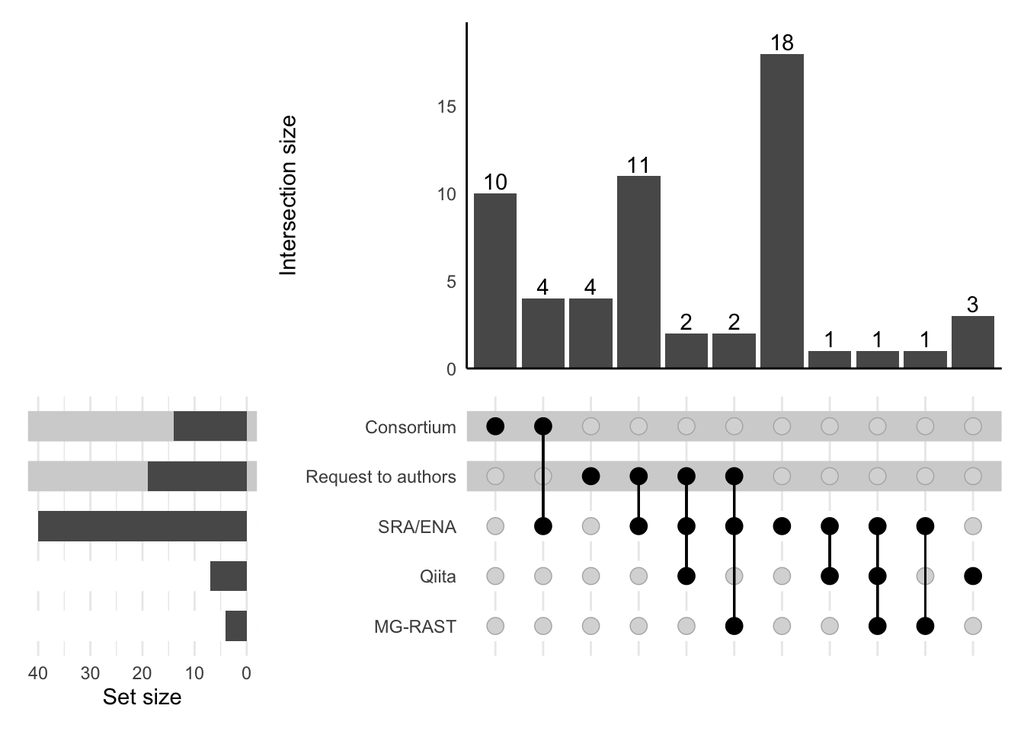

```r
upset(data.set2
      ,intersect = sets
      ,height_ratio = 0.75,
      ,sort_intersections = FALSE
      ,intersections = intersections
      ,keep_empty_groups = FALSE
      ,sort_sets = FALSE
      ,min_size = 1
      ,min_degree = 1
      ,name=""
      ,base_annotations=list("Intersection size" = intersection_size(bar_number_threshold = 1) # show all numbers on top of bars
                              + scale_y_continuous(expand=expansion(mult=c(0, 0.1))) # add space on top of bars
                              + theme(panel.grid.major = element_blank(),
                                      panel.grid.minor = element_blank(),
                                      axis.line = element_line(colour = 'black')))
      ,stripes = c('white', 'white', 'white', 'lightgray', 'lightgray')

)
```

```r
ggsave('upset_datasources.png', bg="transparent", width=6, height=3.5, dpi=300)
```

# Sequencing and data combination

```r
seq.cols <- c("seq_platforms.454.", "seq_platforms.illumina.",
              "seq_platforms.ion_torrent.", "seq_platforms.other.",
              "seq_platforms_other")
sequencing.platform <- data %>%
  select(all_of(seq.cols)) %>%
  mutate(., seq_platforms.missing. = (is.na(seq_platforms.454.) &
                                      is.na(seq_platforms.illumina.)  &
                                      is.na(seq_platforms.ion_torrent.) &
                                      is.na(seq_platforms.other.)) * 1)
sequencing.platform %>%
  select(c(seq_platforms.454.:seq_platforms.other., seq_platforms.missing.)) %>%
  mutate_all(., ~replace(as.numeric(.), is.na(.), 0)) %>%
  summarize(across(seq_platforms.454.:seq_platforms.missing., sum)) %>%
  pivot_longer(cols=everything(), names_to = 'platform', values_to = 'count') %>%
  mutate(., percent = round(count / 60, 2))
```

```
## # A tibble: 5 × 3
##   platform                   count percent
##   <chr>                      <dbl>   <dbl>
## 1 seq_platforms.454.            28    0.47
## 2 seq_platforms.illumina.       40    0.67
## 3 seq_platforms.ion_torrent.     5    0.08
## 4 seq_platforms.other.           3    0.05
## 5 seq_platforms.missing.         1    0.02
```

```r
sequencing.platform %>%
  filter(seq_platforms.other. == 1) %>%
  select(seq_platforms_other)
```

```
## # A tibble: 3 × 1
##   seq_platforms_other
##   <chr>
## 1 "PGM, Miniseq"
## 2 "Roche 454"
## 3 "PsychChip, Immunochip, Metabochip, Affymetrix 6.0, Axiom, HumanHap300, Hap61…
```

And then we want the combinations

```r
sequencing.platform %>%
  filter(., seq_platforms.missing. == 0) %>%
  select(c(seq_platforms.illumina., seq_platforms.454., seq_platforms.ion_torrent.)) %>%
  group_by(seq_platforms.illumina., seq_platforms.454., seq_platforms.ion_torrent.) %>%
  count() %>%
  mutate(., perc = round(n / 60, 2)) %>%
  arrange(desc(seq_platforms.illumina.), desc(seq_platforms.454.), desc(seq_platforms.ion_torrent.))
```

```
## # A tibble: 7 × 5
## # Groups:   seq_platforms.illumina., seq_platforms.454.,
## #   seq_platforms.ion_torrent. [7]
##   seq_platforms.illumina. seq_platforms.454. seq_platforms.ion_tor…¹     n  perc
##   <chr>                   <chr>              <chr>                   <int> <dbl>
## 1 1                       1                  1                           2  0.03
## 2 1                       1                  0                          21  0.35
## 3 1                       0                  1                           2  0.03
## 4 1                       0                  0                          15  0.25
## 5 0                       1                  1                           1  0.02
## 6 0                       1                  0                           4  0.07
## 7 0                       0                  0                          14  0.23
## # ℹ abbreviated name: ¹seq_platforms.ion_torrent.
```

# Hypervariable regions

We also want to look at the number of hypervariable regions reported and number of hypervariable regions used. We’ll start by pulling out the hypervariable region columns.

```r
hv.rename <- function(c){
  c.new <- str_replace(substr(c, 18, 20), pattern='[.]', '')
  return(c.new)
}
#hv.rename('hypervar_regions.V4.')
hypervar <- scoping %>%
  filter(., as.numeric(design_info.hypervariable_region.) == 1) %>%
  select(contains('hypervar_re')) %>%
  rename_with(., .fn = hv.rename, .cols = contains('.V')) %>%
  rename(., c(other='hypervar_regions.Other.')) %>%
  mutate(., V56 = grepl('V56', hypervar_regions_other) * 1) %>%
  mutate(., other = replace(other, hypervar_regions_other == 'V56', 0))
dim(hypervar)
```

```
## [1] 50 14
```

Note the number here is different from the previous because we’re looking at **all** studies and not just the ones that were more outcome or exposure associated.

```r
hypervar %>%
  select(-c(hypervar_regions_other)) %>%
  select(c(V12:V46, V56, V68, other)) %>%
  mutate_all(., ~as.numeric(.)) %>%
  mutate_all(., ~replace(., is.na(.), 0)) %>%
  summarize(across(V12:other, sum)) %>%
  pivot_longer(cols = everything(), names_to = 'region', values_to = 'count') %>%
  mutate(., percent = round(count / 60, 2))
```

```
## # A tibble: 13 × 3
##    region count percent
##    <chr>  <dbl>   <dbl>
##  1 V12       20    0.33
##  2 V13       16    0.27
##  3 V2         7    0.12
##  4 V23        1    0.02
##  5 V3        13    0.22
##  6 V34       29    0.48
##  7 V35       17    0.28
##  8 V4        40    0.67
##  9 V45        6    0.1
## 10 V46        3    0.05
## 11 V56        6    0.1
## 12 V68        1    0.02
## 13 other      7    0.12
```

And then I’d like the number of regions covered.

```r
hypervar %>%
  select(-c(hypervar_regions_other)) %>%
  mutate_all(., ~as.numeric(.)) %>%
  mutate_all(., ~replace(., is.na(.), 0)) %>%
  rowwise() %>%
  mutate(., row_sum = sum(c_across(is.numeric))) %>%
  mutate(., row_sum2 = case_when((row_sum == 1) ~ '1',
                                 (row_sum <= 3) ~ '2-3',
                                 (row_sum > 3) ~ '4 or more')) %>%
  group_by(row_sum2) %>%
  count() %>%
  ungroup() %>%
  mutate(., `%` = n / sum(n))
```

```
## # A tibble: 3 × 3
##   row_sum2      n   `%`
##   <chr>     <int> <dbl>
## 1 1            14  0.28
## 2 2-3          14  0.28
## 3 4 or more    22  0.44
```

And then we’re going to build a heatmap across the region combinations and number of studies

```r
hv.hm <- hypervar %>%
  select(., -c(hypervar_regions_other)) %>%
  mutate_all(., ~as.numeric(.)) %>%
  mutate_all(., ~replace(., is.na(.), 0)) %>%
  select(c(V12:V46, V56, V68, other)) %>%
  group_by(across(everything())) %>%
  summarise(Count = n(), .groups = 'drop') %>%
  filter(Count > 0) %>%
  arrange(., desc(Count)) %>%
  mutate(., row_id = 1:length(Count)) %>%
  mutate(., row_id = max(row_id) - row_id + 1)
```

And then we make a heat map of regions which is unattractive

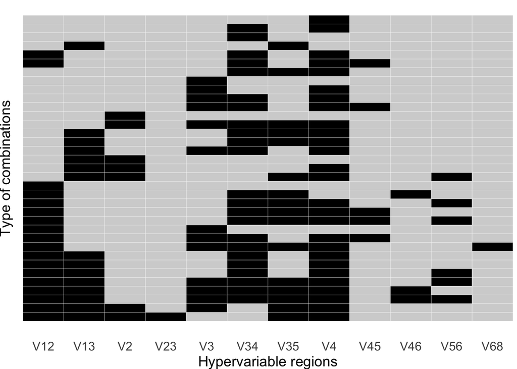

```r
heatmap_plot <- hv.hm %>%
  #head(13) %>%
  mutate(., row_id = row_id - min(row_id)) %>%
  pivot_longer(., cols = c(starts_with('V')), names_to = 'region') %>%
  select(., row_id, region, value) %>%
  ggplot(., aes(x = row_id, y = region, fill = factor(value))) +
  coord_flip() +
 geom_tile(color = "white") +
  scale_fill_manual(values = c("0" = "lightgray", "1" = "black"),
                    name="Used in Study?", labels=c("No","Yes")) +
  scale_x_continuous(breaks=seq(0,34, by =2))+
  xlab("Type of combinations") +
  ylab("Hypervariable regions") +
  theme_minimal() +
  theme(axis.text.x = element_text(angle = 0, hjust = 0.5, size = 12),
        axis.text.y = element_text(size = 12),
        axis.title.x = element_text(size = 14),
        axis.title.y = element_text(angle = 90, hjust = 0.5, size=14)) +
  theme(legend.position = "none",
        plot.margin = margin(0, 0, 0, 0, "cm"),
        axis.text.y=element_blank(),
        axis.ticks.y=element_blank(),
        panel.grid.major = element_blank(),
        panel.grid.minor = element_blank()
        )
heatmap_plot
```

And a barplot with the number of studies that used each combination of hypervariable regions.

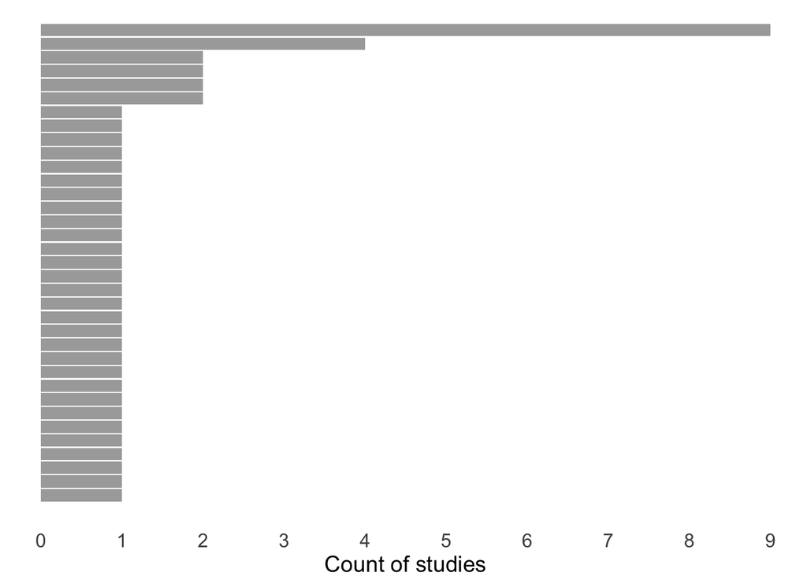

```r
region.barplot <- hv.hm %>%
  #head(13) %>%
  mutate(., row_id = row_id - min(row_id)) %>%
  mutate(., as.factor(row_id)) %>%
  ggplot(., aes(x = row_id, y = Count)) +
  geom_bar(stat = "identity", fill = "darkgray") +
  coord_flip() +
  theme_minimal() +
  ylab("Count of studies") +
  xlab(NULL) +
  scale_y_continuous(breaks = seq(0,9, by=1)) +
  theme(axis.text.x = element_text(angle = 0, hjust = 0.5, size=12),
        axis.title.x = element_text(size = 14)) +
  theme(axis.text.y = element_blank(),
        axis.ticks.y = element_blank(),
        panel.grid.major = element_blank(),
        panel.grid.minor = element_blank(),
        plot.margin = margin(0, 0, 0, 0, "cm"))
region.barplot
```

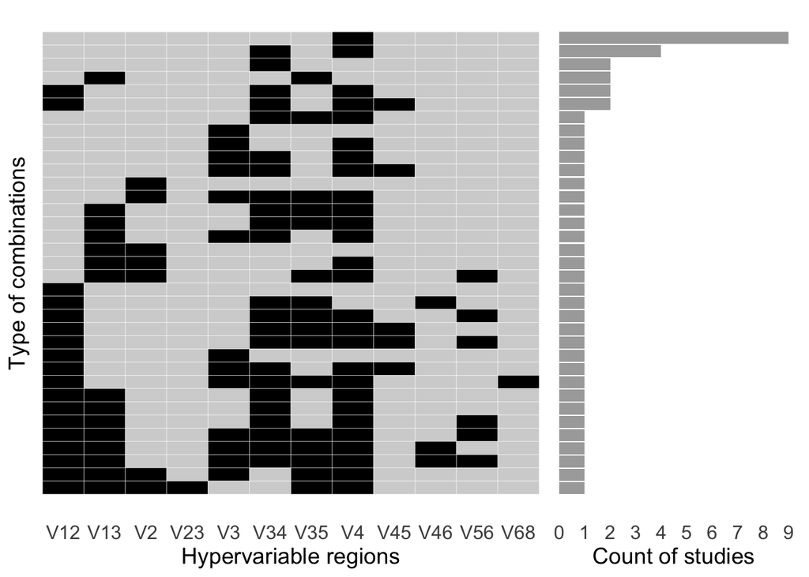

```r
combined_plot <- heatmap_plot + region.barplot +
  plot_layout(ncol = 2, widths = c(2, 1))

combined_plot
```

```r
ggsave("combinedplot1.png", bg="transparent", width = 6, height = 6, dpi = 300)
```

# Table Construction Method

We’ll code the table construction methods.

```r
table.type <- data %>%
  column_to_rownames('doi') %>%
  select(c(otus, asvs, starts_with('otu_type'))) %>%
  mutate_at(., .vars=vars(starts_with('otu_type.')), .funs=as.numeric) %>%
  mutate(., otu_type = case_when(
    ((otus == 'No') & (asvs == 'No')) | (is.na(otus) & is.na(asvs)) ~ 'neither',
    `otu_type.open_ref.`== 1 & `otu_type.de_novo.`!= 1 & `otu_type.closed_ref.`!= 1 ~ "open reference",
    `otu_type.de_novo.`==1 & `otu_type.open_ref.`!= 1 & `otu_type.closed_ref.`!=1 ~ "de novo",
    `otu_type.closed_ref.`==1 & `otu_type.de_novo.`!=1 & `otu_type.open_ref.` != 1 ~ "closed reference",
    ((`otu_type.de_novo.` == 1 & `otu_type.closed_ref.` == 1)) ~ 'mixed',
    (asvs == 'Yes' & otus != "Yes") ~ "asvs",
    `otu_type.unclear.` == 1 | `otu_type.not_described.` == 1 ~ 'unclear',
    .default = 'help'
    )
   ) %>%
 mutate(., den_clus = case_when(
   (otus == "Yes" & asvs != "Yes") | (otus == "Yes" & asvs == NA) ~ "otus",
   (asvs == 'Yes' & otus != "Yes") | (asvs == "Yes" & otus == NA)~ "asvs",
   (asvs == "Unclear/Not described") & (otus == "Unclear/Not described") ~ "unclear",
   (otus == "Yes" & asvs == "Yes") ~ "both"
   )
  ) %>%
  mutate(., otu_type2 = replace(otu_type == "closed reference",
                                (otu_type %in% c('unclear', 'mixed', "open reference")) | is.na(otu_type),
                                NA))
```

```r
table(table.type$otu_type)
```

```
##
##             asvs closed reference          de novo             help
##               12               18                8                2
##            mixed          neither   open reference          unclear
##                4                5                1               10
```

And the I’d like to look at the 10 papers wiwth unclear clustering methods.

```r
table.type %>% filter(., otu_type == 'unclear')
```

```
##                              otus asvs otu_type.de_novo. otu_type.open_ref.
## 10.1111/apt.15375             Yes   No                 0                  0
## 10.1371/journal.pone.0062578  Yes   No                 0                  0
## 10.1016/j.gpb.2018.03.009     Yes   No                 0                  0
## 10.1016/j.tube.2018.02.006    Yes  Yes                 0                  0
## 10.1038/s41531-021-00156-z    Yes  Yes                 0                  0
## 10.1038/s41598-018-32413-2    Yes   No                 0                  0
## 10.1371/journal.pcbi.1010066  Yes   No                 0                  0
## 10.3389/fcimb.2020.00129      Yes  Yes                 0                  0
## 10.1128/mbio.01018-16         Yes   No                 0                  0
## 10.1128/msystems.00797-20     Yes  Yes                 0                  0
##                              otu_type.closed_ref. otu_type.unclear.
## 10.1111/apt.15375                               0                 1
## 10.1371/journal.pone.0062578                    0                 1
## 10.1016/j.gpb.2018.03.009                       0                 1
## 10.1016/j.tube.2018.02.006                      0                 1
## 10.1038/s41531-021-00156-z                      0                 1
## 10.1038/s41598-018-32413-2                      0                 1
## 10.1371/journal.pcbi.1010066                    0                 0
## 10.3389/fcimb.2020.00129                        0                 1
## 10.1128/mbio.01018-16                           0                 0
## 10.1128/msystems.00797-20                       0                 1
##                              otu_type.not_described. otu_type den_clus
## 10.1111/apt.15375                                  0  unclear     otus
## 10.1371/journal.pone.0062578                       0  unclear     otus
## 10.1016/j.gpb.2018.03.009                          0  unclear     otus
## 10.1016/j.tube.2018.02.006                         0  unclear     both
## 10.1038/s41531-021-00156-z                         0  unclear     both
## 10.1038/s41598-018-32413-2                         0  unclear     otus
## 10.1371/journal.pcbi.1010066                       1  unclear     otus
## 10.3389/fcimb.2020.00129                           0  unclear     both
## 10.1128/mbio.01018-16                              1  unclear     otus
## 10.1128/msystems.00797-20                          0  unclear     both
##                              otu_type2
## 10.1111/apt.15375                   NA
## 10.1371/journal.pone.0062578        NA
## 10.1016/j.gpb.2018.03.009           NA
## 10.1016/j.tube.2018.02.006          NA
## 10.1038/s41531-021-00156-z          NA
## 10.1038/s41598-018-32413-2          NA
## 10.1371/journal.pcbi.1010066        NA
## 10.3389/fcimb.2020.00129            NA
## 10.1128/mbio.01018-16               NA
## 10.1128/msystems.00797-20           NA
```

# Analyses conducted

```r
lookup <- c( descriptive="analyses_perf.descriptive."
            ,alpha_diversity="analyses_perf.alpha."
            ,beta_diversity="analyses_perf.beta."
            ,differential_abundance="analyses_perf.differenital_abundance."
            ,sample_classifier="analyses_perf.sample_classification."
            ,core_microbiome="analyses_perf.core_microbiome."
            ,co_occurance="analyses_perf.co_occurance."
            ,other="analyses_perf.other."
            )
analysis.perf <- data %>%
  column_to_rownames('doi') %>%
  select(starts_with('analyses_perf')) %>%
  rename(all_of(lookup)) %>%
  filter(., (!(apply(is.na(select(., descriptive:other)), MARGIN = 1, FUN=any))))

analysis.count <- analysis.perf %>%
  select(-c(analyses_perf_other)) %>%
  mutate_all(., ~replace(as.numeric(.), is.na(.), 0)) %>%
  filter(., (apply(., MARGIN = 1, FUN=sum)) > 0)

analysis.count %>%
  summarize(., across(everything(), sum)) %>%
  pivot_longer(cols=everything(), names_to = 'analysis', values_to = 'count') %>%
  mutate(., percent = round(count / 60, 2))
```

```
## # A tibble: 8 × 3
##   analysis               count percent
##   <chr>                  <dbl>   <dbl>
## 1 descriptive               11    0.18
## 2 alpha_diversity           44    0.73
## 3 beta_diversity            41    0.68
## 4 differential_abundance    44    0.73
## 5 sample_classifier         21    0.35
## 6 core_microbiome            8    0.13
## 7 co_occurance               4    0.07
## 8 other                      6    0.1
```

And then I also want the number of analyses performed.

```r
analysis.count %>%
  mutate(., num.analysis = rowSums(., na.rm = TRUE)) %>%
  group_by(num.analysis) %>%
  count()
```

```
## # A tibble: 6 × 2
## # Groups:   num.analysis [6]
##   num.analysis     n
##          <dbl> <int>
## 1            1     8
## 2            2     9
## 3            3    13
## 4            4    14
## 5            5     8
## 6            6     3
```

```r
analysis.count %>%
  mutate(., num.analysis = rowSums(., na.rm = TRUE)) %>%
  summarize(median = quantile(num.analysis, 0.5),
            q1 = quantile(num.analysis, 0.25),
            q3 = quantile(num.analysis, 0.75),
            geq3 = sum(num.analysis >= 3),
            geq3p = mean(num.analysis >= 3))
```

```
##   median q1 q3 geq3     geq3p
## 1      3  2  4   38 0.6909091
```

## Upset Plot

And then I’d like to look at a combination of studies.

```r
analy.bool <- analysis.count %>%
  mutate_all(., function(x){return(x == 1)})
ana.overlap <- analy.bool %>%
  group_by(., alpha_diversity, beta_diversity, differential_abundance,
              sample_classifier, descriptive, core_microbiome, co_occurance) %>%
  count() %>%
  select(-c())

set.names <- c('sample classifier'
              ,'differential abundance'
              ,'beta diversity'
              ,'alpha diversity'
              )
inter.names <- list('alpha diversity'
                    ,c('alpha diversity', 'beta diversity')
                    ,c('alpha diversity', 'beta diversity', 'differential abundance')
                    ,c('alpha diversity', 'beta diversity', 'differential abundance','sample classifier')
                    ,c('alpha diversity', 'beta diversity', 'sample classifier')
                    ,c('alpha diversity',  'differential abundance')
                    ,c('alpha diversity', 'differential abundance','sample classifier')
                    ,c('alpha diversity', 'sample classifier')
                   ,'beta diversity'
                   ,c('beta diversity', 'differential abundance')
                   ,c('beta diversity', 'differential abundance', 'sample classifier')
                   ,c('beta diversity', 'sample classifier')
                   ,'differential abundance'
                   ,c('differential abundance', 'sample classifier')
                   ,'sample classifier'
                   )
rename <- c(`alpha diversity` = 'alpha_diversity'
           ,`beta diversity` = 'beta_diversity'
           ,`differential abundance` = 'differential_abundance'
           ,`sample classifier` = 'sample_classifier'
           )
```

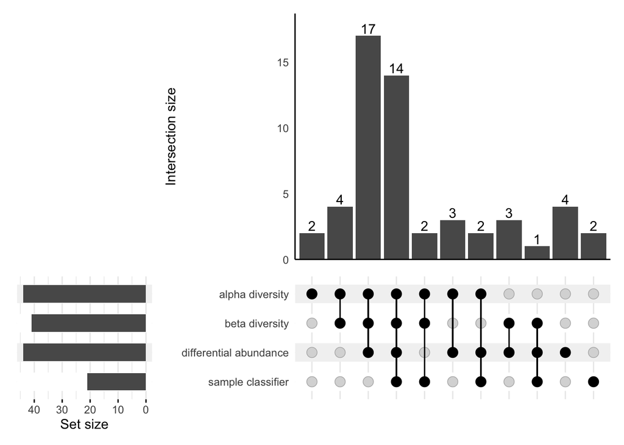

```r
analysis.count %>%
  mutate_all(., ~(. == 1)) %>%
  rename(all_of(rename)) %>%
  select(all_of(set.names)) %>%
upset(data = .
     ,intersect = set.names
     ,sort_sets = FALSE
     ,sort_intersections = FALSE
     ,intersections = inter.names
     ,width_ratio=0.3,
     ,keep_empty_groups = FALSE,
     sort_ratio_numerator = FALSE
     ,min_size = 1
     ,min_degree = 1
     ,name=""
     ,base_annotations=list("Intersection size" = intersection_size(bar_number_threshold = 1) # show all numbers on top of bars
                            + scale_y_continuous(expand=expansion(mult=c(0, 0.1))) # add space on top of bars
                            + theme(panel.grid.major = element_blank(),
                                  panel.grid.minor = element_blank(),
                                  axis.line = element_line(colour = 'black'))),
      set_sizes = (upset_set_size()
                   + theme(axis.ticks.x = element_line())),
      )
```

```r
ggsave("upset_analysis.png", bg="transparent", width=6, height=3, dpi=300)
```

## Diversity Level

I also want to look at the minimum level where diversity analyses were conducted.

```r
div.levels <- data %>%
  filter(., doi %in% rownames(analysis.count)) %>%
  column_to_rownames('doi') %>%
  select(c(starts_with('analyses_perf.'),
           starts_with('alpha_level'),
           starts_with('beta_level'),
           starts_with('diff_abund_level'),
           starts_with('class_level')
           )) %>%
  mutate(., beta_level.otu_asv. = replace(`beta_level.otu_asv.`,
                                          `beta_level.not_described.` == 'phylotypes',
                                          1)
         , beta_level.not_described. = replace(beta_level.not_described.,
                                               beta_level.not_described. == 'phylotypes',
                                               0)) %>%
   mutate_all(., ~as.numeric(replace(., is.na(.), '-1'))) %>%
   mutate(., min_alpha_level = case_when(`alpha_level.otu_asv.`==1 ~ "otu/asv",
                                         `alpha_level.species.`==1 ~ "species",
                                         `alpha_level.genus.`==1 ~ "genus",
                                         `alpha_level.family.`==1 ~ "family",
                                         `alpha_level.order.`==1 ~ "order",
                                         `alpha_level.class.` == 1 ~ 'class',
                                         `alpha_level.phylum.` == 1 ~ "phylum",
                                        `alpha_level.not_described.` == 1 ~ "unclear")
           , min_beta_level = case_when(`beta_level.otu_asv.`==1 ~ "otu/asv",
                                        `beta_level.species.` == 1 ~ "species",
                                        `beta_level.genus.` ==1 ~ "genus",
                                        `beta_level.family.`==1 ~ "family",
                                        `beta_level.order.` == 1 ~ "order",
                                        `beta_level.class.` ==1 ~ "class",
                                        `beta_level.phylum.` == 1 ~ "phylum",
                                        `beta_level.not_described.`==1 ~"unclear")
          ,min_diff_abund_level=case_when(`diff_abund_level.otu_asv.`==1 ~"otu/asv",
                                          `diff_abund_level.species.`==1 ~"species",
                                          `diff_abund_level.genus.`==1 ~"genus",
                                          `diff_abund_level.family.`==1 ~"family",
                                          `diff_abund_level.order.`==1 ~"order",
                                          `diff_abund_level.class.`==1 ~"class",
                                          `diff_abund_level.phylum.`==1 ~"phylum",
                                          `diff_abund_level.not_described.` == 1 ~ "unclear")
          ,min_class_level=case_when(`class_level.otu_asv.`==1~"otu/asv",
                                     `class_level.species.`==1~"species",
                                     `class_level.genus.`==1~"genus",
                                     `class_level.family.`==1~"family",
                                     `class_level.order.`==1~"order",
                                     `class_level.class.`==1~"class",
                                     `class_level.phylum.`==1~"phylum",
                                     `class_level.not_described.`==1~"unclear")) %>%
     mutate(., min_alpha_level = replace(min_alpha_level, `analyses_perf.alpha.` == 0, NA)
             , min_beta_level = replace(min_beta_level, `analyses_perf.beta.` == 0, NA)
             , min_diff_abund_level = replace(min_diff_abund_level,
                                              `analyses_perf.differenital_abundance.` == 0, NA)
             , min_class_level = replace(min_class_level, `analyses_perf.sample_classification.` == 0, NA))
```

And now that we have the minimum level, we’re going to tabulate them…

```r
alpha.lvl <- div.levels %>%
  count(min_alpha_level) %>%
  rename(any_of(c(alpha = 'n', taxa='min_alpha_level')))
beta.lvl <- div.levels %>%
  count(min_beta_level) %>%
  rename(all_of(c(beta = 'n', taxa = 'min_beta_level')))
da.lvl <- div.levels %>%
  count(min_diff_abund_level) %>%
  rename(all_of(c(da = 'n', taxa = 'min_diff_abund_level')))
ml.lvl <- div.levels %>%
  count(min_class_level) %>%
  rename(all_of(c(ml = 'n', taxa = 'min_class_level')))

level.analysis <- alpha.lvl %>%
  full_join(., beta.lvl, by = join_by(taxa)) %>%
  full_join(., da.lvl, by = join_by(taxa)) %>%
  full_join(., ml.lvl, by = join_by(taxa)) %>%
  mutate(., taxa = replace(taxa, is.na(taxa), 'not analyzed')
          , level.order = c(3, 1, 2, 6, 7, 4, 5)) %>%
  arrange(level.order) %>%
  select(-c(level.order)) %>%
  mutate_all(., ~replace(., is.na(.), 0))

level.analysis
```

```
##           taxa alpha beta da ml
## 1      otu/asv    29   30 19 12
## 2      species     5    3  5  0
## 3        genus     4    4 18  7
## 4       family     0    1  0  0
## 5       phylum     0    0  2  0
## 6      unclear     6    2  0  2
## 7 not analyzed    11   15 11 34
```

# Table construction method, Number of hypervariable regions, and the analytical level

```r
data.cross <- data %>%
  column_to_rownames('doi') %>%
    select(c(starts_with('hypervar_regions'), 'asvs', 'otus',
             starts_with('otu_type'),
             starts_with('anal'),
             starts_with('alpha_level'),
             starts_with('beta_level'),
             starts_with('diff_abund_level'),
             starts_with('class_level'))) %>%
  mutate(., asvs = case_when(asvs == 'Yes' ~ 1,
                             asvs == 'No' ~ 0,
                             asvs == 'Unclear/Not described' ~ 2,
                             is.na(asvs) ~ 2)
          , otus = case_when(otus == 'Yes' ~ 1,
                             otus == 'No' ~ 0,
                             otus == 'Unclear/Not described' ~ 2,
                             is.na(otus) ~ 2)
         ) %>%
  select(-c(hypervar_regions.Other.)) %>%
  separate(hypervar_regions_other, c('hypervar_regions.other1.','hypervar_regions.other2.'), ", ") %>%
  mutate(., hypervar_regions.other1. = (!is.na(hypervar_regions.other1.)) * 1
          , hypervar_regions.other2. = (!is.na(hypervar_regions.other2.)) * 1) %>%
  mutate(., beta_level.otu_asv. = replace(`beta_level.otu_asv.`,
                                          `beta_level.not_described.` == 'phylotypes',
                                          1)
         , beta_level.not_described. = replace(beta_level.not_described.,
                                               beta_level.not_described. == 'phylotypes',
                                               0)) %>%
   mutate_all(., ~as.numeric(replace(., is.na(.), 0))) %>%
   mutate(., num_regions = apply(select(., starts_with('hypervar_regions.')), MARGIN = 1, FUN=sum)
           , otu_type = case_when((`otu_type.de_novo.` + otu_type.closed_ref. + otu_type.open_ref.) > 1 ~ 'mixed',
                                   (`otu_type.unclear.` == 1 | `otu_type.not_described.` == 1) ~ 'unclear',
                                   (otu_type.de_novo. == 1) ~ 'de novo',
                                   (otu_type.closed_ref. == 1) ~ 'closed ref',
                                   (otu_type.open_ref. == 1) ~ 'open ref',
                                   (asvs == 1 & otus != 1) ~ 'asvs')
          , min_alpha_level = case_when(`alpha_level.otu_asv.`== 1 ~ "otu/asv",
                                         `alpha_level.species.`== 1 ~ "species",
                                         `alpha_level.genus.`== 1 ~ "genus",
                                         `alpha_level.family.`== 1 ~ "family",
                                         `alpha_level.order.`== 1 ~ "order or higher",
                                         `alpha_level.class.` == 1 ~ 'order or higher',
                                         `alpha_level.phylum.` == 1 ~ "order or higher",
                                         `alpha_level.not_described.` == 1 ~ "unclear")
           , min_beta_level = case_when(`beta_level.otu_asv.`==1 ~ "otu/asv",
                                        `beta_level.species.` == 1 ~ "species",
                                        `beta_level.genus.` ==1 ~ "genus",
                                        `beta_level.family.`==1 ~ "family",
                                        `beta_level.order.` == 1 ~ "order or higher",
                                        `beta_level.class.` ==1 ~ "order or higher",
                                        `beta_level.phylum.` == 1 ~ "order or higher",
                                        `beta_level.not_described.`==1 ~"unclear")
          ,min_diff_abund_level=case_when(`diff_abund_level.otu_asv.`==1 ~"otu/asv",
                                          `diff_abund_level.species.`==1 ~"species",
                                          `diff_abund_level.genus.`==1 ~"genus",
                                          `diff_abund_level.family.`==1 ~"family",
                                          `diff_abund_level.order.`==1 ~"order or higher",
                                          `diff_abund_level.class.`==1 ~"order or higher",
                                          `diff_abund_level.phylum.`==1 ~"order or higher",
                                          `diff_abund_level.not_described.` == 1 ~ "unclear")
           ) %>%
  select(., c(num_regions,
              otu_type, min_alpha_level, min_beta_level, min_diff_abund_level,
              analyses_perf.alpha., analyses_perf.beta.,
              analyses_perf.differenital_abundance.,)) %>%
  filter(., otu_type %in% c('de novo', 'closed ref', 'asvs')) %>%
  filter(., num_regions > 0) %>%
  filter(., apply(select(., starts_with('anal')), MARGIN = 1, FUN = sum) > 0) %>%
  mutate(., multi_region = replace((num_regions > 1) * 1 + 1, num_regions == 0, NA)
          , alpha_feature = replace((min_alpha_level == 'otu/asv') * 1, analyses_perf.alpha. != 1, NA)
          , beta_feature = replace((min_beta_level == 'otu/asv') * 1, analyses_perf.beta. != 1, NA)
          , da_feature = replace((min_diff_abund_level == 'otu/asv') * 1, analyses_perf.differenital_abundance. != 1, NA)
          , otu_type2 = (otu_type == 'closed ref') * 1
        )

dim(data.cross)
```

```
## [1] 32 13
```

```r
data.cross %>% group_by(otu_type2) %>% count()
```

```
## # A tibble: 2 × 2
## # Groups:   otu_type2 [2]
##   otu_type2     n
##       <dbl> <int>
## 1         0    19
## 2         1    13
```

```r
data.cross %>% group_by(multi_region) %>% count()
```

```
## # A tibble: 2 × 2
## # Groups:   multi_region [2]
##   multi_region     n
##          <dbl> <int>
## 1            1    10
## 2            2    22
```

```r
data.cross %>% group_by(multi_region) %>% count()
```

```
## # A tibble: 2 × 2
## # Groups:   multi_region [2]
##   multi_region     n
##          <dbl> <int>
## 1            1    10
## 2            2    22
```

## Number of hypervraible regions and table construction method

```r
num.regions <- data.cross %>%
  group_by(otu_type2, multi_region) %>%
  count() %>%
  ungroup() %>%
  pivot_wider(., id_cols = otu_type2,
              names_from = multi_region,
              values_from = n,
              values_fill = 0)
num.regions
```

```
## # A tibble: 2 × 3
##   otu_type2   `1`   `2`
##       <dbl> <int> <int>
## 1         0     6    13
## 2         1     4     9
```

```r
num.regions %>% select(c(`1`, `2`)) %>%fisher.test()
```

```
##
##  Fisher's Exact Test for Count Data
##
## data:  .
## p-value = 1
## alternative hypothesis: true odds ratio is not equal to 1
## 95 percent confidence interval:
##  0.1798418 6.5409326
## sample estimates:
## odds ratio
##   1.037249
```

```r
num.regions %>% select(c(`1`, `2`)) %>% chisq.test()
```

```
##
##  Pearson's Chi-squared test with Yates' continuity correction
##
## data:  .
## X-squared = 0, df = 1, p-value = 1
```

## Analyses performed

```r
data.cross %>% select(starts_with('anal')) %>% summarize(across(everything(), sum))
```

```
##   analyses_perf.alpha. analyses_perf.beta.
## 1                   26                  25
##   analyses_perf.differenital_abundance.
## 1                                    30
```

```r
data.cross %>% select(starts_with('anal')) %>%
  summarize(across(everything(), mean)) %>%
  mutate_all(., ~round(., 3))
```

```
##   analyses_perf.alpha. analyses_perf.beta.
## 1                0.812               0.781
##   analyses_perf.differenital_abundance.
## 1                                 0.938
```

## Number of regions vs analysis

### Alpha Diversity

```r
alpha.rgn <- data.cross %>%
  group_by(multi_region, analyses_perf.alpha.) %>%
  count() %>%
  ungroup() %>%
  pivot_wider(id_cols = multi_region,
              names_from = analyses_perf.alpha.,
              values_from = n,
              values_fill = 0)
alpha.rgn
```

```
## # A tibble: 2 × 3
##   multi_region   `0`   `1`
##          <dbl> <int> <int>
## 1            1     1     9
## 2            2     5    17
```

```r
alpha.rgn %>% select(c(`0`, `1`)) %>% fisher.test()
```

```
##
##  Fisher's Exact Test for Count Data
##
## data:  .
## p-value = 0.6367
## alternative hypothesis: true odds ratio is not equal to 1
## 95 percent confidence interval:
##  0.007205218 4.307842321
## sample estimates:
## odds ratio
##   0.387944
```

```r
alpha.rgn %>% select(c(`0`, `1`)) %>% chisq.test()
```

```
##
##  Pearson's Chi-squared test with Yates' continuity correction
##
## data:  .
## X-squared = 0.13427, df = 1, p-value = 0.714
```

### Beta Diversity

```r
beta.rgn <- data.cross %>%
  group_by(multi_region, analyses_perf.beta.) %>%
  count() %>%
  ungroup() %>%
  pivot_wider(id_cols = multi_region,
              names_from = analyses_perf.beta.,
              values_from = n,
              values_fill = 0)
beta.rgn
```

```
## # A tibble: 2 × 3
##   multi_region   `0`   `1`
##          <dbl> <int> <int>
## 1            1     1     9
## 2            2     6    16
```

```r
beta.rgn %>% select(c(`0`, `1`)) %>% fisher.test()
```

```
##
##  Fisher's Exact Test for Count Data
##
## data:  .
## p-value = 0.3871
## alternative hypothesis: true odds ratio is not equal to 1
## 95 percent confidence interval:
##  0.005812333 3.200416779
## sample estimates:
## odds ratio
##  0.3061133
```

```r
beta.rgn %>% select(c(`0`, `1`)) %>% chisq.test()
```

```
##
##  Pearson's Chi-squared test with Yates' continuity correction
##
## data:  .
## X-squared = 0.40229, df = 1, p-value = 0.5259
```

### Differential abundance

```r
da.rgn <- data.cross %>%
  group_by(multi_region, analyses_perf.differenital_abundance.) %>%
  count() %>%
  ungroup() %>%
  pivot_wider(id_cols = multi_region,
              names_from = analyses_perf.differenital_abundance.,
              values_from = n,
              values_fill = 0)
da.rgn
```

```
## # A tibble: 2 × 3
##   multi_region   `0`   `1`
##          <dbl> <int> <int>
## 1            1     1     9
## 2            2     1    21
```

```r
da.rgn %>% select(c(`0`, `1`)) %>% fisher.test()
```

```
##
##  Fisher's Exact Test for Count Data
##
## data:  .
## p-value = 0.5343
## alternative hypothesis: true odds ratio is not equal to 1
## 95 percent confidence interval:
##    0.0267763 191.3920800
## sample estimates:
## odds ratio
##   2.265713
```

```r
da.rgn %>% select(c(`0`, `1`)) %>% chisq.test()
```

```
##
##  Pearson's Chi-squared test with Yates' continuity correction
##
## data:  .
## X-squared = 0, df = 1, p-value = 1
```

## Analysis by table construction

### Alpha Diversity

```r
alpha.count <- data.cross %>%
  group_by(otu_type2, analyses_perf.alpha.) %>%
  count() %>%
  ungroup() %>%
  pivot_wider(id_cols = otu_type2,
              names_from = analyses_perf.alpha.,
              values_from = n,
              values_fill = 0)
alpha.count
```

```
## # A tibble: 2 × 3
##   otu_type2   `0`   `1`
##       <dbl> <int> <int>
## 1         0     5    14
## 2         1     1    12
```

```r
alpha.count %>% select(c(`0`, `1`)) %>% fisher.test()
```

```
##
##  Fisher's Exact Test for Count Data
##
## data:  .
## p-value = 0.3606
## alternative hypothesis: true odds ratio is not equal to 1
## 95 percent confidence interval:
##    0.3807602 219.0080089
## sample estimates:
## odds ratio
##   4.117887
```

```r
alpha.count %>% select(c(`0`, `1`)) %>% chisq.test()
```

```
##
##  Pearson's Chi-squared test with Yates' continuity correction
##
## data:  .
## X-squared = 0.74743, df = 1, p-value = 0.3873
```

### Beta Diversity

```r
beta.count <- data.cross %>%
  group_by(otu_type2, analyses_perf.beta.) %>%
  count() %>%
  ungroup() %>%
  pivot_wider(id_cols = otu_type2,
              names_from = analyses_perf.beta.,
              values_from = n,
              values_fill = 0)
beta.count
```

```
## # A tibble: 2 × 3
##   otu_type2   `0`   `1`
##       <dbl> <int> <int>
## 1         0     7    12
## 2         1     0    13
```

```r
beta.count %>% select(c(`0`, `1`)) %>% fisher.test()
```

```
##
##  Fisher's Exact Test for Count Data
##
## data:  .
## p-value = 0.02517
## alternative hypothesis: true odds ratio is not equal to 1
## 95 percent confidence interval:
##  1.207834      Inf
## sample estimates:
## odds ratio
##        Inf
```

```r
beta.count %>% select(c(`0`, `1`)) %>% chisq.test()
```

```
##
##  Pearson's Chi-squared test with Yates' continuity correction
##
## data:  .
## X-squared = 4.1643, df = 1, p-value = 0.04129
```

```r
data.cross %>%
  group_by(otu_type, analyses_perf.beta.) %>%
  count() %>%
  ungroup() %>%
  pivot_wider(id_cols = otu_type,
              names_from = analyses_perf.beta.,
              values_from = n,
              values_fill = 0)
```

```
## # A tibble: 3 × 3
##   otu_type     `0`   `1`
##   <chr>      <int> <int>
## 1 asvs           4     9
## 2 closed ref     0    13
## 3 de novo        3     3
```

### Differential Abundance

```r
da.count <- data.cross %>%
  group_by(otu_type2, analyses_perf.differenital_abundance.) %>%
  count() %>%
  ungroup() %>%
  pivot_wider(id_cols = otu_type2,
              names_from = analyses_perf.differenital_abundance.,
              values_from = n,
              values_fill = 0)
da.count
```

```
## # A tibble: 2 × 3
##   otu_type2   `0`   `1`
##       <dbl> <int> <int>
## 1         0     1    18
## 2         1     1    12
```

```r
da.count %>% select(c(`0`, `1`)) %>% fisher.test()
```

```
##
##  Fisher's Exact Test for Count Data
##
## data:  .
## p-value = 1
## alternative hypothesis: true odds ratio is not equal to 1
## 95 percent confidence interval:
##   0.00806061 56.62207915
## sample estimates:
## odds ratio
##  0.6753982
```

```r
da.count %>% select(c(`0`, `1`)) %>% chisq.test()
```

```
##
##  Pearson's Chi-squared test with Yates' continuity correction
##
## data:  .
## X-squared = 0, df = 1, p-value = 1
```

## Table construction and analysis level

### Alpha

```r
alpha.tab.lvl.count <- data.cross %>%
  filter(., !is.na(alpha_feature)) %>%
  group_by(otu_type2, alpha_feature) %>%
  count() %>%
  ungroup() %>%
  pivot_wider(id_cols = otu_type2,
              names_from = alpha_feature,
              values_from = n,
              values_fill = 0)
alpha.tab.lvl.count
```

```
## # A tibble: 2 × 3
##   otu_type2   `0`   `1`
##       <dbl> <int> <int>
## 1         0     3    11
## 2         1     2    10
```

```r
alpha.tab.lvl.count %>% select(c(`0`, `1`)) %>% fisher.test()
```

```
##
##  Fisher's Exact Test for Count Data
##
## data:  .
## p-value = 1
## alternative hypothesis: true odds ratio is not equal to 1
## 95 percent confidence interval:
##   0.1256739 19.3037986
## sample estimates:
## odds ratio
##   1.347599
```

```r
alpha.tab.lvl.count %>% select(c(`0`, `1`)) %>% chisq.test()
```

```
##
##  Pearson's Chi-squared test with Yates' continuity correction
##
## data:  .
## X-squared = 1.5115e-31, df = 1, p-value = 1
```

### Beta Diversity

```r
beta.tab.lvl.count <- data.cross %>%
  filter(., !is.na(beta_feature)) %>%
  group_by(otu_type2, beta_feature) %>%
  count() %>%
  ungroup() %>%
  pivot_wider(id_cols = otu_type2,
              names_from = beta_feature,
              values_from = n,
              values_fill = 0)
beta.tab.lvl.count
```

```
## # A tibble: 2 × 3
##   otu_type2   `0`   `1`
##       <dbl> <int> <int>
## 1         0     5     6
## 2         1     3    10
```

```r
beta.tab.lvl.count %>% select(c(`0`, `1`)) %>% fisher.test()
```

```
##
##  Fisher's Exact Test for Count Data
##
## data:  .
## p-value = 0.3905
## alternative hypothesis: true odds ratio is not equal to 1
## 95 percent confidence interval:
##   0.3593893 23.8778891
## sample estimates:
## odds ratio
##   2.657092
```

```r
beta.tab.lvl.count %>% select(c(`0`, `1`)) %>% chisq.test()
```

```
##
##  Pearson's Chi-squared test with Yates' continuity correction
##
## data:  .
## X-squared = 0.52448, df = 1, p-value = 0.4689
```

### Differential Abundance

```r
da.tab.lvl.count <- data.cross %>%
  filter(., !is.na(da_feature)) %>%
  group_by(otu_type2, da_feature) %>%
  count() %>%
  ungroup() %>%
  pivot_wider(id_cols = otu_type2,
              names_from = da_feature,
              values_from = n,
              values_fill = 0)
da.tab.lvl.count
```

```
## # A tibble: 2 × 3
##   otu_type2   `0`   `1`
##       <dbl> <int> <int>
## 1         0    11     7
## 2         1     6     6
```

```r
da.tab.lvl.count %>% select(c(`0`, `1`)) %>% fisher.test()
```

```
##
##  Fisher's Exact Test for Count Data
##
## data:  .
## p-value = 0.7106
## alternative hypothesis: true odds ratio is not equal to 1
## 95 percent confidence interval:
##  0.2824375 8.7325650
## sample estimates:
## odds ratio
##   1.547568
```

```r
da.tab.lvl.count %>% select(c(`0`, `1`)) %>% chisq.test()
```

```
##
##  Pearson's Chi-squared test with Yates' continuity correction
##
## data:  .
## X-squared = 0.050905, df = 1, p-value = 0.8215
```

## Number of regions and table collapse level

### Alpha Diversity

```r
alpha.reg.count <- data.cross %>%
  filter(., analyses_perf.alpha. == 1) %>%
  group_by(multi_region, alpha_feature) %>%
  count() %>%
  ungroup() %>%
  pivot_wider(id_cols = multi_region,
              names_from = alpha_feature,
              values_from = n,
              values_fill = 0)
alpha.reg.count
```

```
## # A tibble: 2 × 3
##   multi_region   `1`   `0`
##          <dbl> <int> <int>
## 1            1     9     0
## 2            2    12     5
```

```r
alpha.reg.count %>% select(c(`0`, `1`)) %>% fisher.test()
```

```
##
##  Fisher's Exact Test for Count Data
##
## data:  .
## p-value = 0.1285
## alternative hypothesis: true odds ratio is not equal to 1
## 95 percent confidence interval:
##  0.000000 1.909277
## sample estimates:
## odds ratio
##          0
```

```r
alpha.reg.count %>% select(c(`0`, `1`)) %>% chisq.test()
```

```
##
##  Pearson's Chi-squared test with Yates' continuity correction
##
## data:  .
## X-squared = 1.6573, df = 1, p-value = 0.198
```

I want to see this by table construction method.

```r
alpha.rgn.cotu.count <-  data.cross %>%
  filter(., (analyses_perf.alpha. == 1) & (otu_type2 == 1)) %>%
  group_by(multi_region, alpha_feature) %>%
  count() %>%
  ungroup() %>%
  pivot_wider(id_cols = multi_region,
              names_from = alpha_feature,
              values_from = n,
              values_fill = 0)
alpha.rgn.cotu.count
```

```
## # A tibble: 2 × 3
##   multi_region   `1`   `0`
##          <dbl> <int> <int>
## 1            1     4     0
## 2            2     6     2
```

```r
alpha.rgn.cotu.count %>% select(c(`0`, `1`)) %>% fisher.test()
```

```
##
##  Fisher's Exact Test for Count Data
##
## data:  .
## p-value = 0.5152
## alternative hypothesis: true odds ratio is not equal to 1
## 95 percent confidence interval:
##   0.00000 11.08641
## sample estimates:
## odds ratio
##          0
```

```r
alpha.rgn.cotu.count %>% select(c(`0`, `1`)) %>% chisq.test()
```

```
##
##  Pearson's Chi-squared test with Yates' continuity correction
##
## data:  .
## X-squared = 0.075, df = 1, p-value = 0.7842
```

And then ASVs and de novo OTUs

```r
alpha.rgn.dotu.count <-  data.cross %>%
  filter(., (analyses_perf.alpha. == 1) & (otu_type2 == 0)) %>%
  group_by(multi_region, alpha_feature) %>%
  count() %>%
  ungroup() %>%
  pivot_wider(id_cols = multi_region,
              names_from = alpha_feature,
              values_from = n,
              values_fill = 0)
alpha.rgn.dotu.count
```

```
## # A tibble: 2 × 3
##   multi_region   `1`   `0`
##          <dbl> <int> <int>
## 1            1     5     0
## 2            2     6     3
```

```r
alpha.rgn.dotu.count %>% select(c(`0`, `1`)) %>% fisher.test()
```

```
##
##  Fisher's Exact Test for Count Data
##
## data:  .
## p-value = 0.2582
## alternative hypothesis: true odds ratio is not equal to 1
## 95 percent confidence interval:
##  0.000000 4.328298
## sample estimates:
## odds ratio
##          0
```

```r
alpha.rgn.dotu.count %>% select(c(`0`, `1`)) %>% chisq.test()
```

```
##
##  Pearson's Chi-squared test with Yates' continuity correction
##
## data:  .
## X-squared = 0.60337, df = 1, p-value = 0.4373
```

### Beta diversity

```r
beta.reg.count <- data.cross %>%
  filter(., !is.na(beta_feature)) %>%
  group_by(multi_region, beta_feature) %>%
  count() %>%
  ungroup() %>%
  pivot_wider(id_cols = multi_region,
              names_from = beta_feature,
              values_from = n,
              values_fill = 0)
beta.reg.count
```

```
## # A tibble: 2 × 3
##   multi_region   `1`   `0`
##          <dbl> <int> <int>
## 1            1     8     0
## 2            2     8     8
```

```r
beta.reg.count %>% select(c(`0`, `1`)) %>% fisher.test()
```

```
##
##  Fisher's Exact Test for Count Data
##
## data:  .
## p-value = 0.02224
## alternative hypothesis: true odds ratio is not equal to 1
## 95 percent confidence interval:
##  0.0000000 0.8709645
## sample estimates:
## odds ratio
##          0
```

```r
beta.reg.count %>% select(c(`0`, `1`)) %>% chisq.test()
```

```
##
##  Pearson's Chi-squared test with Yates' continuity correction
##
## data:  .
## X-squared = 3.9609, df = 1, p-value = 0.04657
```

And then Closed Ref OTUs

```r
beta.reg.count.cotu <- data.cross %>%
  filter(., !is.na(beta_feature) & (otu_type2 == 1)) %>%
  group_by(multi_region, beta_feature) %>%
  count() %>%
  ungroup() %>%
  pivot_wider(id_cols = multi_region,
              names_from = beta_feature,
              values_from = n,
              values_fill = 0)
beta.reg.count.cotu
```

```
## # A tibble: 2 × 3
##   multi_region   `1`   `0`
##          <dbl> <int> <int>
## 1            1     4     0
## 2            2     6     3
```

```r
beta.reg.count.cotu %>% select(c(`0`, `1`)) %>% fisher.test()
```

```
##
##  Fisher's Exact Test for Count Data
##
## data:  .
## p-value = 0.4965
## alternative hypothesis: true odds ratio is not equal to 1
## 95 percent confidence interval:
##  0.000000 5.665105
## sample estimates:
## odds ratio
##          0
```

```r
beta.reg.count.cotu %>% select(c(`0`, `1`)) %>% chisq.test()
```

```
##
##  Pearson's Chi-squared test with Yates' continuity correction
##
## data:  .
## X-squared = 0.36412, df = 1, p-value = 0.5462
```

```r
beta.reg.count.dotu <- data.cross %>%
  filter(., !is.na(beta_feature) & (otu_type2 == 0)) %>%
  group_by(multi_region, beta_feature) %>%
  count() %>%
  ungroup() %>%
  pivot_wider(id_cols = multi_region,
              names_from = beta_feature,
              values_from = n,
              values_fill = 0)
beta.reg.count.dotu
```

```
## # A tibble: 2 × 3
##   multi_region   `1`   `0`
##          <dbl> <int> <int>
## 1            1     4     0
## 2            2     2     5
```

```r
beta.reg.count.dotu %>% select(c(`0`, `1`)) %>% fisher.test()
```

```
##
##  Fisher's Exact Test for Count Data
##
## data:  .
## p-value = 0.06061
## alternative hypothesis: true odds ratio is not equal to 1
## 95 percent confidence interval:
##  0.000000 1.363965
## sample estimates:
## odds ratio
##          0
```

```r
beta.reg.count.dotu %>% select(c(`0`, `1`)) %>% chisq.test()
```

```
##
##  Pearson's Chi-squared test with Yates' continuity correction
##
## data:  .
## X-squared = 2.7533, df = 1, p-value = 0.09706
```

### Differential Abundance

```r
da.reg.count <- data.cross %>%
  filter(., !is.na(da_feature)) %>%
  group_by(multi_region, da_feature) %>%
  count() %>%
  ungroup() %>%
  pivot_wider(id_cols = multi_region,
              names_from = da_feature,
              values_from = n,
              values_fill = 0)
da.reg.count
```

```
## # A tibble: 2 × 3
##   multi_region   `0`   `1`
##          <dbl> <int> <int>
## 1            1     1     8
## 2            2    16     5
```

```r
da.reg.count %>% select(c(`0`, `1`)) %>% fisher.test()
```

```
##
##  Fisher's Exact Test for Count Data
##
## data:  .
## p-value = 0.001579
## alternative hypothesis: true odds ratio is not equal to 1
## 95 percent confidence interval:
##  0.0008374662 0.4558273831
## sample estimates:
## odds ratio
## 0.04471229
```

```r
da.reg.count %>% select(c(`0`, `1`)) %>% chisq.test()
```

```
##
##  Pearson's Chi-squared test with Yates' continuity correction
##
## data:  .
## X-squared = 8.3775, df = 1, p-value = 0.003799
```

```r
da.reg.count.cotu <- data.cross %>%
  filter(., !is.na(da_feature) & (otu_type2 == 1)) %>%
  group_by(multi_region, da_feature) %>%
  count() %>%
  ungroup() %>%
  pivot_wider(id_cols = multi_region,
              names_from = da_feature,
              values_from = n,
              values_fill = 0)
da.reg.count.cotu
```

```
## # A tibble: 2 × 3
##   multi_region   `1`   `0`
##          <dbl> <int> <int>
## 1            1     3     0
## 2            2     3     6
```

```r
da.reg.count.cotu %>% select(c(`0`, `1`)) %>% fisher.test()
```

```
##
##  Fisher's Exact Test for Count Data
##
## data:  .
## p-value = 0.1818
## alternative hypothesis: true odds ratio is not equal to 1
## 95 percent confidence interval:
##  0.00000 2.11221
## sample estimates:
## odds ratio
##          0
```

```r
da.reg.count.cotu %>% select(c(`0`, `1`)) %>% chisq.test()
```

```
##
##  Pearson's Chi-squared test with Yates' continuity correction
##
## data:  .
## X-squared = 1.7778, df = 1, p-value = 0.1824
```

```r
da.reg.count.dotu1 <- data.cross %>%
  filter(., !is.na(da_feature) & (otu_type2 == 1 )) %>% # Not sure which otu_type2 you want to look at here
  group_by(multi_region, da_feature) %>% # so I just made two versions
  count() %>%
  ungroup() %>%
  pivot_wider(id_cols = multi_region,
              names_from = da_feature,
              values_from = n,
              values_fill = 0)
da.reg.count.dotu1
```

```
## # A tibble: 2 × 3
##   multi_region   `1`   `0`
##          <dbl> <int> <int>
## 1            1     3     0
## 2            2     3     6
```

```r
da.reg.count.dotu0 <- data.cross %>%
  filter(., !is.na(da_feature) & (otu_type2 == 0 )) %>% # Not sure which otu_type2 you want to look at here
  group_by(multi_region, da_feature) %>%
  count() %>%
  ungroup() %>%
  pivot_wider(id_cols = multi_region,
              names_from = da_feature,
              values_from = n,
              values_fill = 0)
da.reg.count.dotu0
```

```
## # A tibble: 2 × 3
##   multi_region   `0`   `1`
##          <dbl> <int> <int>
## 1            1     1     5
## 2            2    10     2
```

```r
da.reg.count.dotu1 %>% select(c(`0`, `1`)) %>% fisher.test()
```

```
##
##  Fisher's Exact Test for Count Data
##
## data:  .
## p-value = 0.1818
## alternative hypothesis: true odds ratio is not equal to 1
## 95 percent confidence interval:
##  0.00000 2.11221
## sample estimates:
## odds ratio
##          0
```

```r
da.reg.count.dotu1 %>% select(c(`0`, `1`)) %>% chisq.test()
```

```
##
##  Pearson's Chi-squared test with Yates' continuity correction
##
## data:  .
## X-squared = 1.7778, df = 1, p-value = 0.1824
```

```r
da.reg.count.dotu0 %>% select(c(`0`, `1`)) %>% fisher.test()
```

```
##
##  Fisher's Exact Test for Count Data
##
## data:  .
## p-value = 0.01282
## alternative hypothesis: true odds ratio is not equal to 1
## 95 percent confidence interval:
##  0.0007808723 0.7710696862
## sample estimates:
## odds ratio
## 0.05204496
```

```r
da.reg.count.dotu0 %>% select(c(`0`, `1`)) %>% chisq.test()
```

```
##
##  Pearson's Chi-squared test with Yates' continuity correction
##
## data:  .
## X-squared = 4.9383, df = 1, p-value = 0.02627
```